# CMPINF 2130 Summer 2021 - Week 04

Dr. Joseph P. Yurko

6/7/2021

## Load packages

```r
library(tidyverse)
```

## Review scatter plot essentials

Let’s use the `iris` data set again and make a scatter plot between the Sepal variables.

**Start simple**

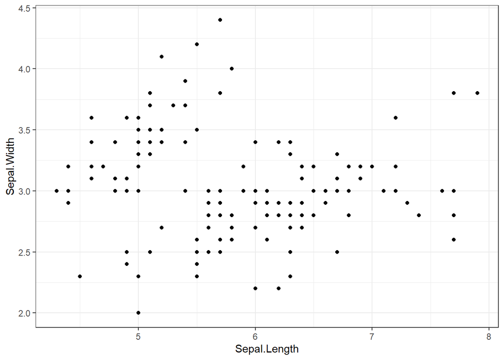

```r
iris %>%
  ggplot(mapping = aes(x = Sepal.Length, y = Sepal.Width)) +
  geom_point() +
  theme_bw()
```

We can add complexity by mapping additional variables to other aesthetics of the geometric object.

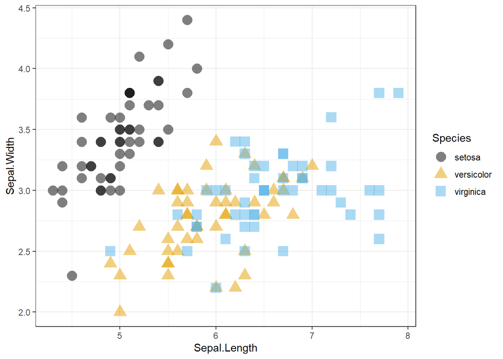

```r
iris %>%
  ggplot(mapping = aes(x = Sepal.Length, y = Sepal.Width)) +
  geom_point(mapping = aes(color = Species,
                           shape = Species),
             size = 4.5, alpha = 0.5) +
  ggthemes::scale_color_colorblind() +
  theme_bw()
```

Coloring by continuous variables.

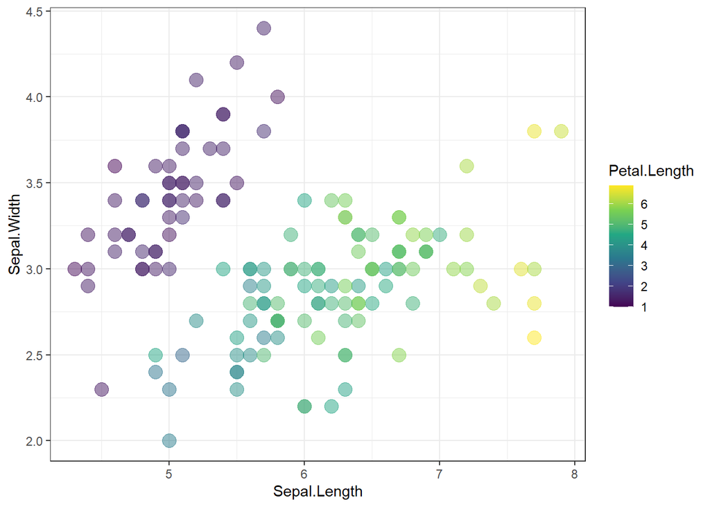

```r
iris %>%
  ggplot(mapping = aes(x = Sepal.Length, y = Sepal.Width)) +
  geom_point(mapping = aes(color = Petal.Length),
             size = 4.5, alpha = 0.5) +
  scale_color_viridis_c() +
  theme_bw()
```

Add further complexity through facets.

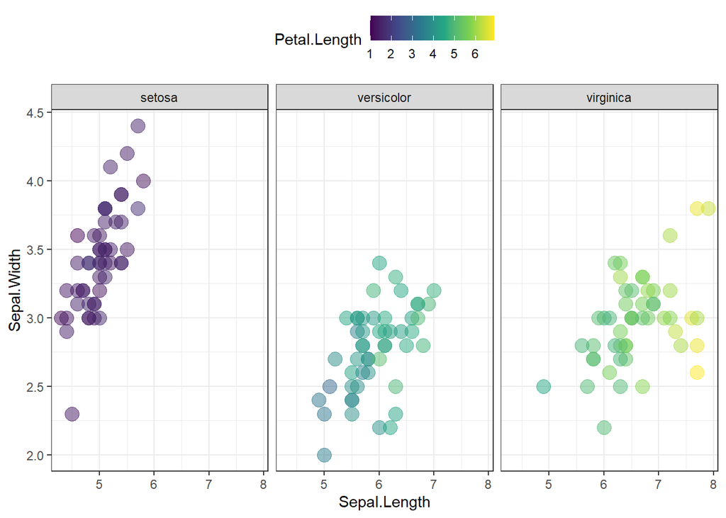

```r
iris %>%
  ggplot(mapping = aes(x = Sepal.Length, y = Sepal.Width)) +
  geom_point(mapping = aes(color = Petal.Length),
             size = 4.5, alpha = 0.5) +
  facet_wrap( ~ Species ) +
  scale_color_viridis_c() +
  theme_bw() +
  theme(legend.position = "top")
```

Create a binary version of `Petal.Width` and map that binary variable to the marker shape.

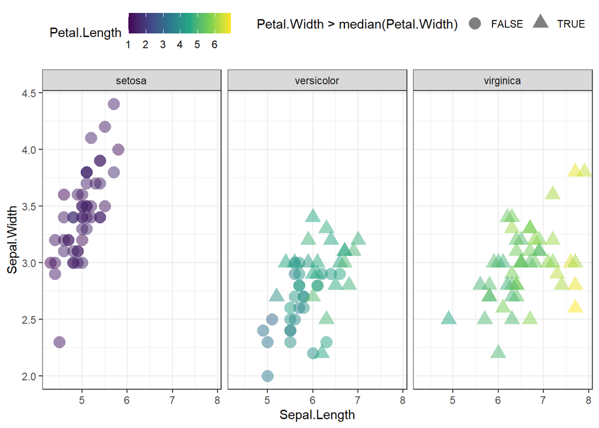

```r
iris %>%
  ggplot(mapping = aes(x = Sepal.Length, y = Sepal.Width)) +
  geom_point(mapping = aes(color = Petal.Length,
                           shape = Petal.Width > median(Petal.Width)),
             size = 4.5, alpha = 0.5) +
  facet_wrap( ~ Species ) +
  scale_color_viridis_c() +
  theme_bw() +
  theme(legend.position = "top")
```

We can keep Petal.Width continuous by mapping it to the marker size and the marker transparency.

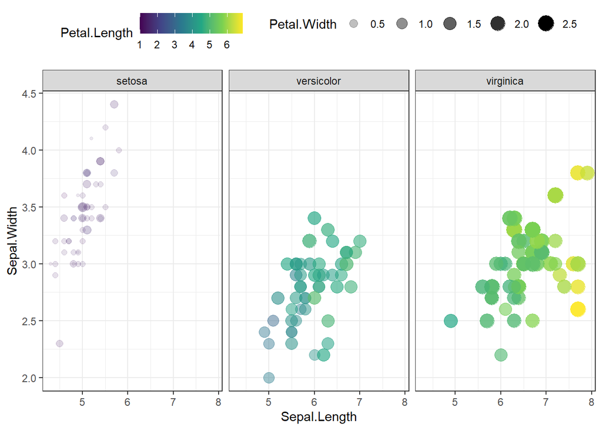

```r
iris %>%
  ggplot(mapping = aes(x = Sepal.Length, y = Sepal.Width)) +
  geom_point(mapping = aes(color = Petal.Length,
                           size = Petal.Width,
                           alpha = Petal.Width)) +
  facet_wrap( ~ Species ) +
  scale_color_viridis_c() +
  theme_bw() +
  theme(legend.position = "top")
```

## Lines, paths, and trends

A line shows continuity in the x-axis ordering.

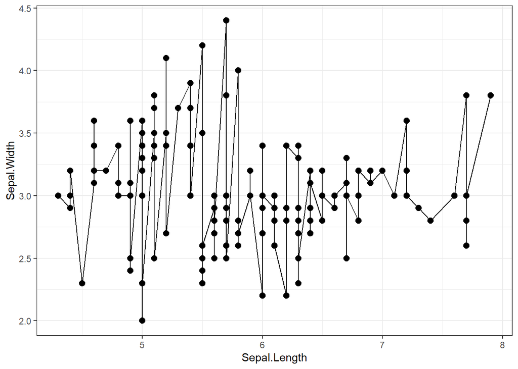

```r
iris %>%
  ggplot(mapping = aes(x = Sepal.Length, y = Sepal.Width)) +
  geom_line() +
  geom_point(size = 2.5) +
  theme_bw()
```

The `geom_line()` is particularly useful when we want to show the **order** of a value with respect to the x-axis. A “RUN PLOT” or “RUN CHART” is one type of a figure where `geom_line()` is the kind of geom to use.

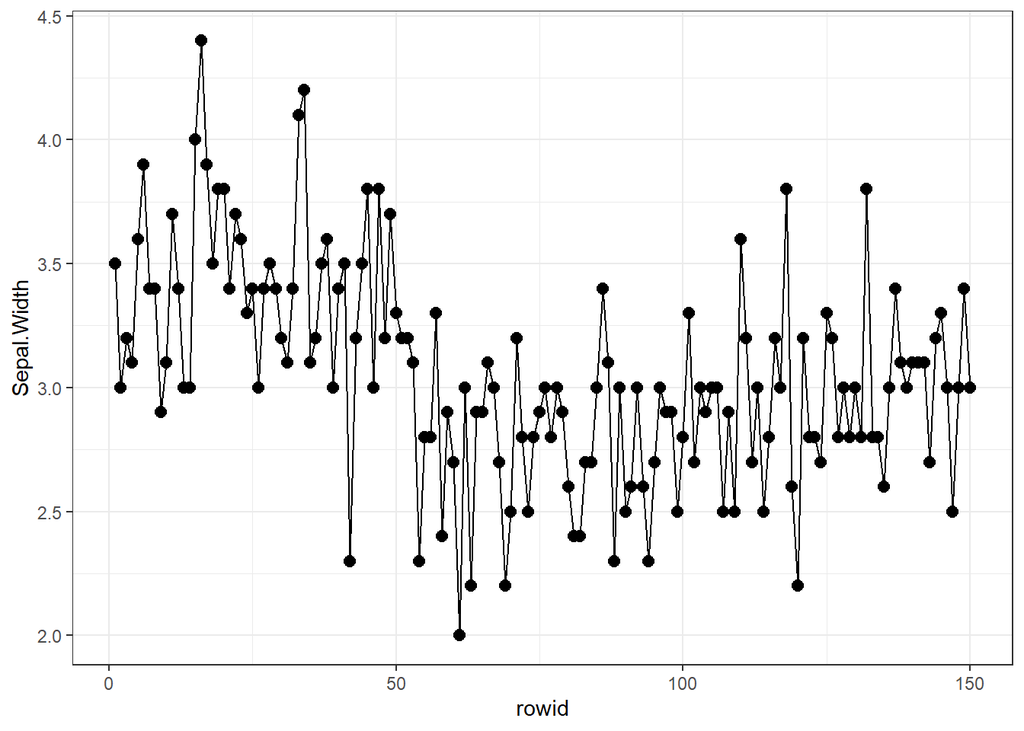

```r
iris %>%
  tibble::rowid_to_column() %>%
  ggplot(mapping = aes(x = rowid, y = Sepal.Width)) +
  geom_line() +
  geom_point(size = 2.5) +
  theme_bw()
```

Trends let us see the “signal through the noise”. We will focus at first on linear relationships between the `y` and `x` aesthetics.

First, remake the scatter plot where we color by Species.

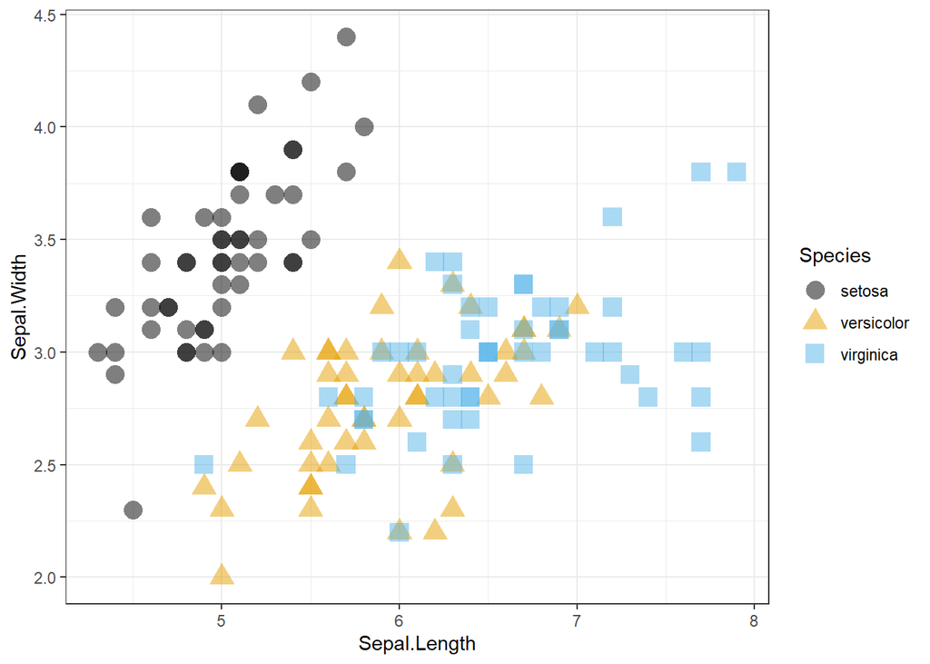

```r
iris %>%
  ggplot(mapping = aes(x = Sepal.Length, y = Sepal.Width)) +
  geom_point(mapping = aes(color = Species,
                           shape = Species),
             size = 4.5, alpha = 0.5) +
  ggthemes::scale_color_colorblind() +
  theme_bw()
```

Add in a trend line to this plot with `geom_smooth()`. Force a linear model with `method = lm`.

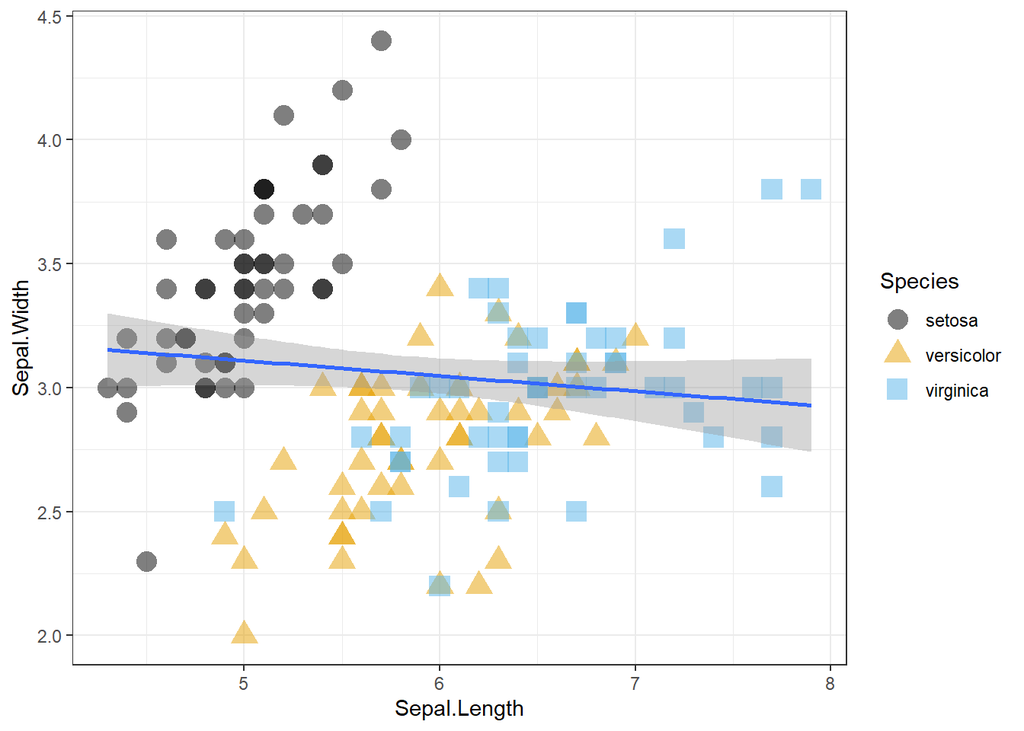

```r
iris %>%
  ggplot(mapping = aes(x = Sepal.Length, y = Sepal.Width)) +
  geom_point(mapping = aes(color = Species,
                           shape = Species),
             size = 4.5, alpha = 0.5) +
  geom_smooth(method = lm) +
  ggthemes::scale_color_colorblind() +
  theme_bw()
```

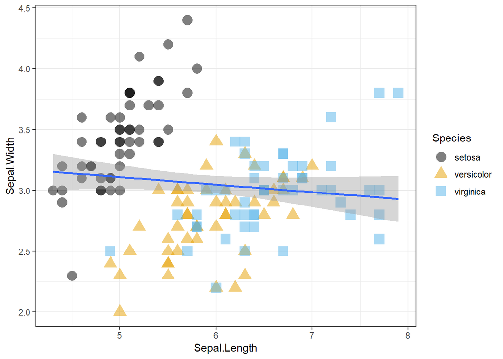

```r
iris %>%
  ggplot(mapping = aes(x = Sepal.Length, y = Sepal.Width)) +
  geom_point(mapping = aes(color = Species,
                           shape = Species),
             size = 4.5, alpha = 0.5) +
  geom_smooth(method = lm,
              formula = y ~ x) +
  ggthemes::scale_color_colorblind() +
  theme_bw()
```

Last week we looked at the correlation coefficients.

```r
iris %>%
  select(starts_with("Sepal.")) %>%
  cor()
```

```
##              Sepal.Length Sepal.Width
## Sepal.Length    1.0000000  -0.1175698
## Sepal.Width    -0.1175698   1.0000000
```

But we know that’s not the case when we consider grouping by the Species.

```r
iris %>%
  select(starts_with("Sepal."), Species) %>%
  group_by(Species) %>%
  group_modify( ~ as.data.frame(cor(.x)))
```

```
## # A tibble: 6 x 3
## # Groups:   Species [3]
##   Species    Sepal.Length Sepal.Width
##   <fct>             <dbl>       <dbl>
## 1 setosa            1           0.743
## 2 setosa            0.743       1
## 3 versicolor        1           0.526
## 4 versicolor        0.526       1
## 5 virginica         1           0.457
## 6 virginica         0.457       1
```

Let’s now map Species to the color aesthetic in `geom_smooth()`.

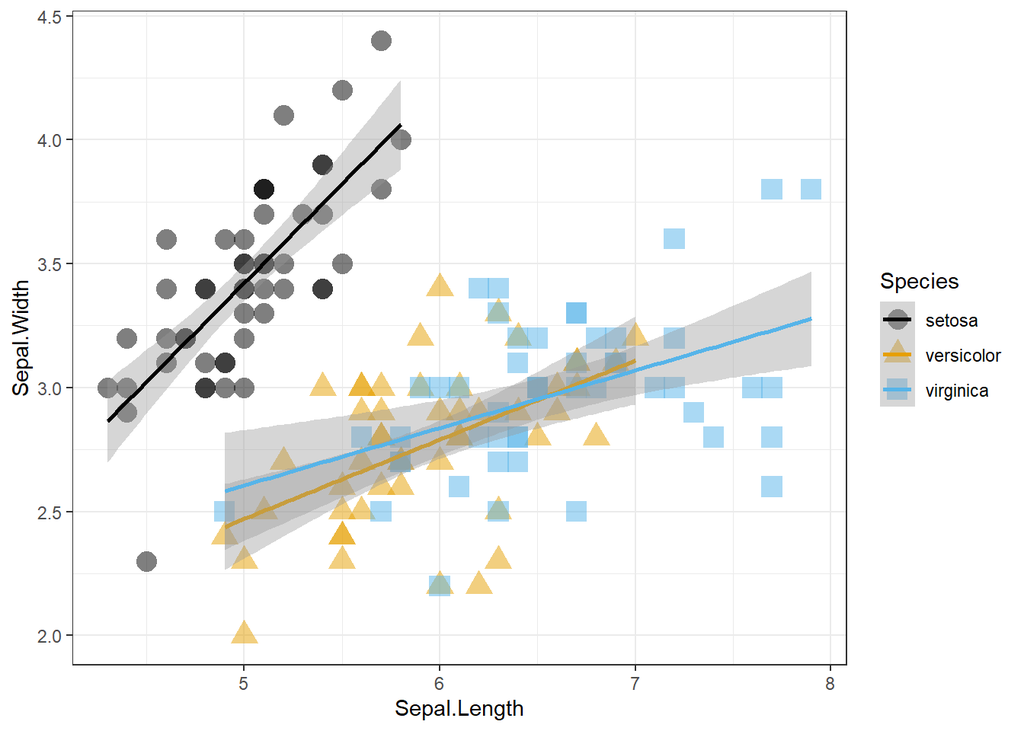

```r
iris %>%
  ggplot(mapping = aes(x = Sepal.Length, y = Sepal.Width)) +
  geom_point(mapping = aes(color = Species,
                           shape = Species),
             size = 4.5, alpha = 0.5) +
  geom_smooth(method = lm,
              formula = y ~ x,
              mapping = aes(color = Species)) +
  ggthemes::scale_color_colorblind() +
  theme_bw()
```

We could have got the same result if we mapped `Species` to `color` in the parent call.

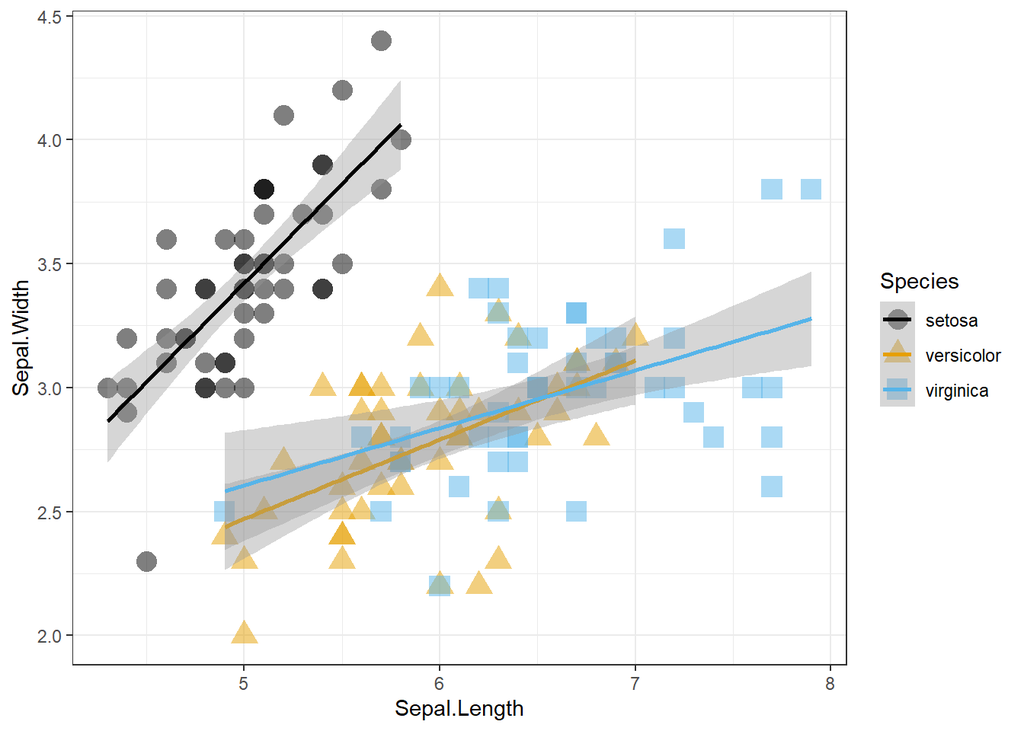

```r
iris %>%
  ggplot(mapping = aes(x = Sepal.Length, y = Sepal.Width,
                       color = Species)) +
  geom_point(mapping = aes(shape = Species),
             size = 4.5, alpha = 0.5) +
  geom_smooth(method = lm,
              formula = y ~ x) +
  ggthemes::scale_color_colorblind() +
  theme_bw()
```

If we do not map color in the parent `ggplot()` call, we can have separate smoothing lines for “all data” and for the individual Species.

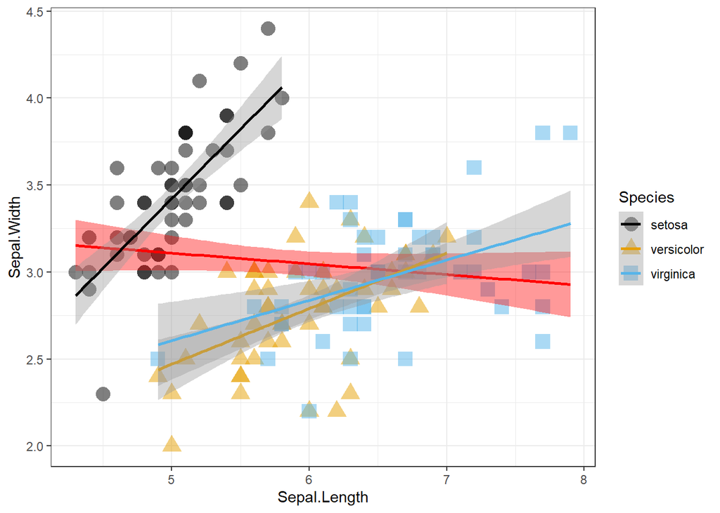

```r
iris %>%
  ggplot(mapping = aes(x = Sepal.Length, y = Sepal.Width)) +
  geom_point(mapping = aes(color = Species,
                           shape = Species),
             size = 4.5, alpha = 0.5) +
  # smooth based on all data
  geom_smooth(method = lm, formula = y ~ x,
              color = 'red', fill = 'red') +
  # smooth per group
  geom_smooth(method = lm, formula = y ~ x,
              mapping = aes(color = Species)) +
  ggthemes::scale_color_colorblind() +
  theme_bw()
```

We can remove the points, by simply **not** including the `geom_point()` layer.

**I DO NOT RECOMMEND THIS TYPE OF FIGURE**

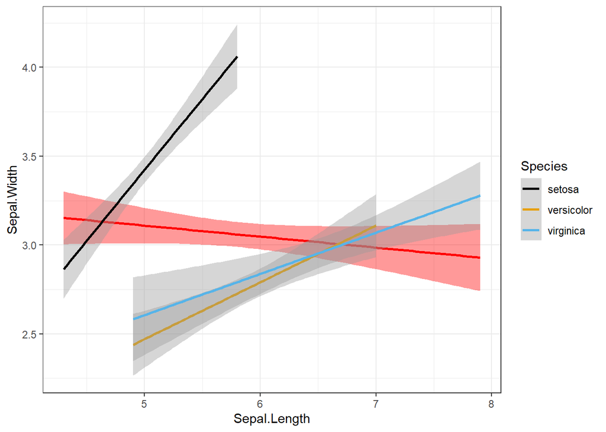

```r
iris %>%
  ggplot(mapping = aes(x = Sepal.Length, y = Sepal.Width)) +
  # smooth based on all data
  geom_smooth(method = lm, formula = y ~ x,
              color = 'red', fill = 'red') +
  # smooth per group
  geom_smooth(method = lm, formula = y ~ x,
              mapping = aes(color = Species)) +
  ggthemes::scale_color_colorblind() +
  theme_bw()
```

For right now, I’ll remove the confidence interval just so we can focus on the trend line.

**BUT I DON’T LIKE TO NORMALLY!!!!!**

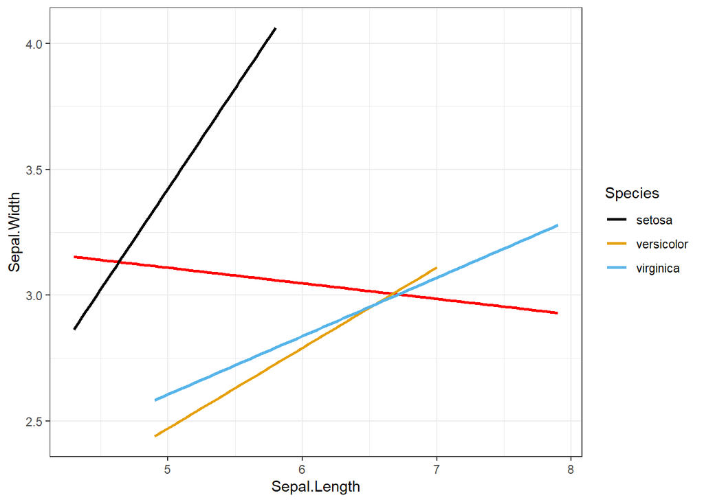

```r
iris %>%
  ggplot(mapping = aes(x = Sepal.Length, y = Sepal.Width)) +
  # smooth based on all data
  geom_smooth(method = lm, formula = y ~ x,
              color = 'red', fill = 'red',
              se = FALSE) +
  # smooth per group
  geom_smooth(method = lm, formula = y ~ x,
              mapping = aes(color = Species),
              se = FALSE) +
  ggthemes::scale_color_colorblind() +
  theme_bw()
```

Lines have similiar aesthetics as points.

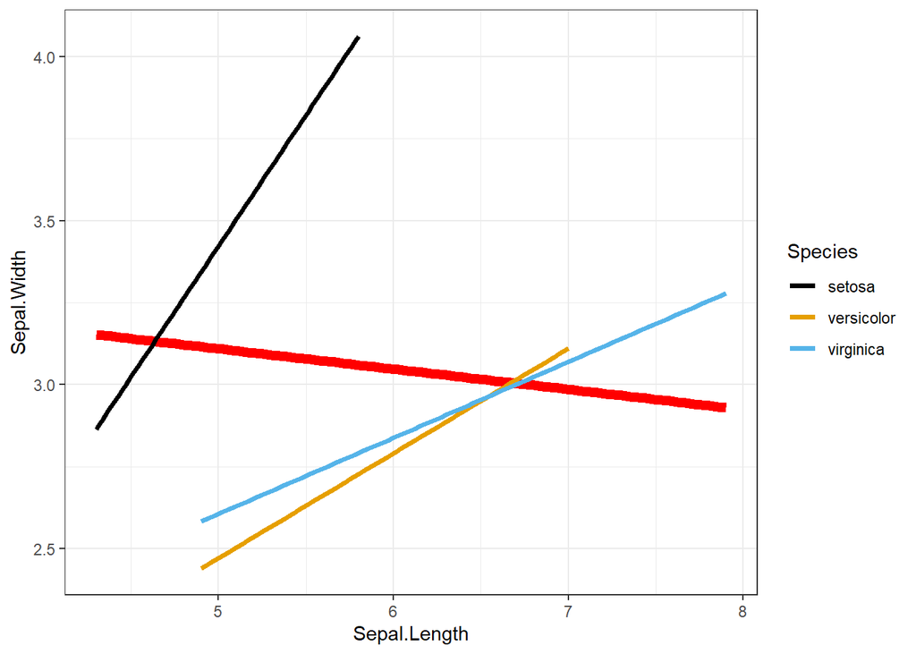

```r
iris %>%
  ggplot(mapping = aes(x = Sepal.Length, y = Sepal.Width)) +
  # smooth based on all data
  geom_smooth(method = lm, formula = y ~ x,
              color = 'red', fill = 'red',
              se = FALSE,
              size = 2.5) +
  # smooth per group
  geom_smooth(method = lm, formula = y ~ x,
              mapping = aes(color = Species),
              se = FALSE,
              size = 1.25) +
  ggthemes::scale_color_colorblind() +
  theme_bw()
```

linetype is analogous to marker shape.

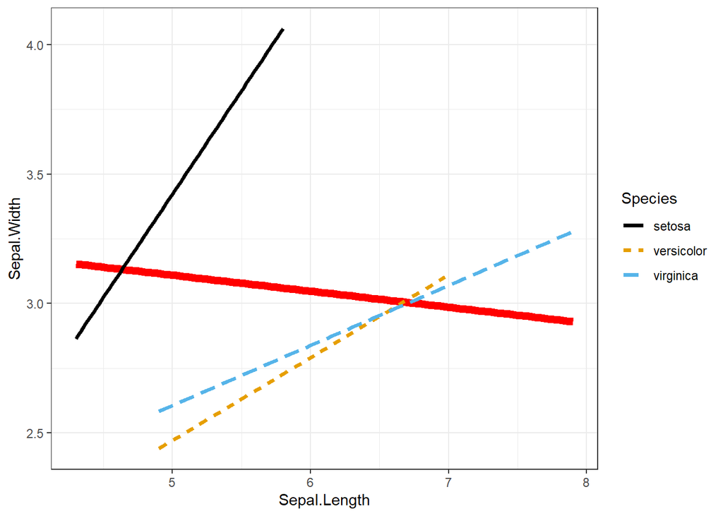

```r
iris %>%
  ggplot(mapping = aes(x = Sepal.Length, y = Sepal.Width)) +
  # smooth based on all data
  geom_smooth(method = lm, formula = y ~ x,
              color = 'red', fill = 'red',
              se = FALSE,
              size = 2.5) +
  # smooth per group
  geom_smooth(method = lm, formula = y ~ x,
              mapping = aes(color = Species,
                            linetype = Species),
              se = FALSE,
              size = 1.25) +
  ggthemes::scale_color_colorblind() +
  theme_bw()
```

We have up to now used `color` to force a grouping of the data “behind the scenes”. We can be more explicit and state that the `group` aesthetic is `Species`.

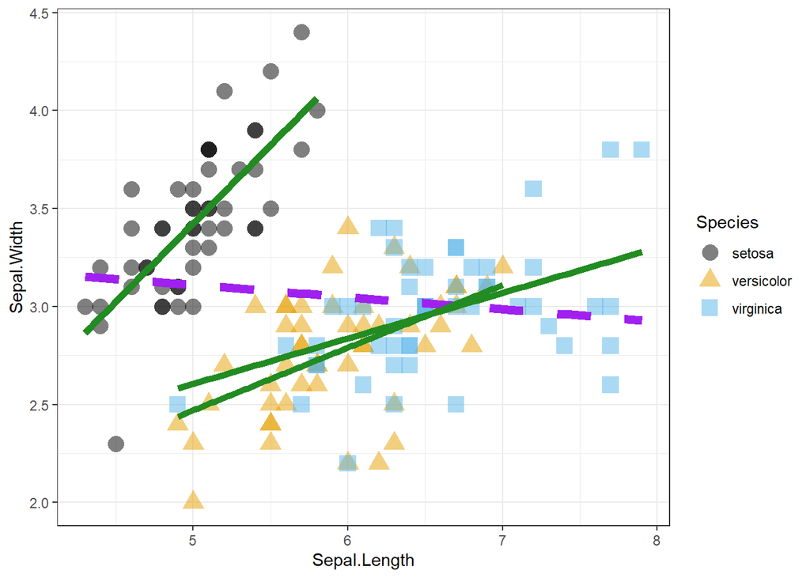

```r
iris %>%
  ggplot(mapping = aes(x = Sepal.Length, y = Sepal.Width)) +
  geom_point(mapping = aes(color = Species,
                           shape = Species),
             size = 4.5, alpha = 0.5) +
  # smooth based on all data
  geom_smooth(method = lm, formula = y ~ x,
              color = 'purple',
              mapping = aes(group = 1),
              se = FALSE,
              size = 2.5, linetype = 'dashed') +
  # smooth per group
  geom_smooth(method = lm, formula = y ~ x,
              mapping = aes(group = Species),
              color = 'forestgreen', size = 2,
              se = FALSE) +
  ggthemes::scale_color_colorblind() +
  theme_bw()
```

## Statistical transformations

Statistical transformation are ways of **deriving** or calculating aesthetics from “raw” data.

Essentially, the variable we will plot on the graph does **not** exist in the raw data set.

Linear models or *smoothers* are one type of statistical transformation, but the simplest one is to **count**.

How many rows exist for each *level* of `Species`.

```r
iris %>% count(Species)
```

```
##      Species  n
## 1     setosa 50
## 2 versicolor 50
## 3  virginica 50
```

Behind the scenes `count()` must first `group_by()` and then `summarize()` the data. Split-Apply-Combine: split the data into separate groups, apply a *summary* function, and combine the data back together.

```r
iris %>%
  group_by(Species) %>%
  summarise(num_rows = n())
```

```
## # A tibble: 3 x 2
##   Species    num_rows
##   <fct>         <int>
## 1 setosa           50
## 2 versicolor       50
## 3 virginica        50
```

Can check that this is correct via filtering.

```r
iris %>%
  filter(Species == 'setosa') %>%
  nrow()
```

```
## [1] 50
```

```r
iris %>%
  filter(Species == 'versicolor') %>%
  nrow()
```

```
## [1] 50
```

```r
iris %>%
  group_by(Species) %>%
  tidyr::nest() %>%
  mutate(num_rows = purrr::map_dbl(data, nrow))
```

```
## # A tibble: 3 x 3
## # Groups:   Species [3]
##   Species    data                  num_rows
##   <fct>      <list>                   <dbl>
## 1 setosa     <tibble[,4] [50 x 4]>       50
## 2 versicolor <tibble[,4] [50 x 4]>       50
## 3 virginica  <tibble[,4] [50 x 4]>       50
```

A bar graph or bar chart is useful to display counts, the taller the bar the more counts!

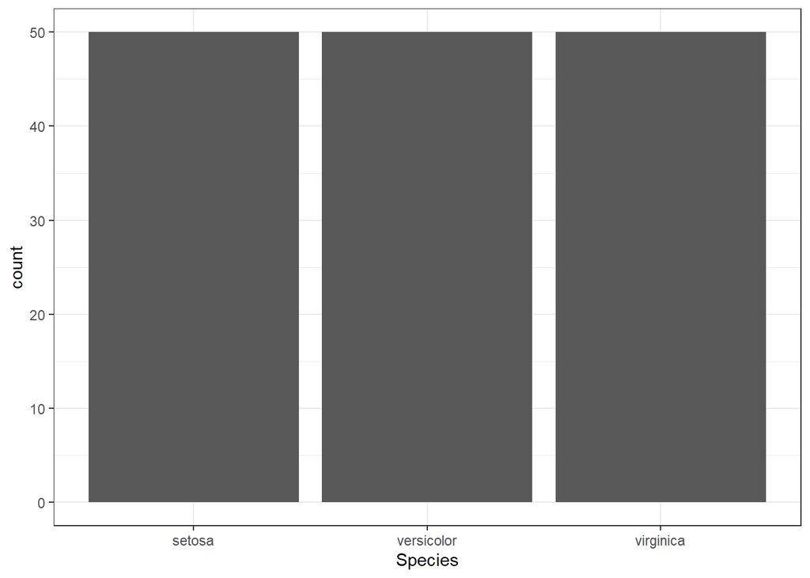

```r
iris %>%
  ggplot(mapping = aes(x = Species)) +
  geom_bar() +
  theme_bw()
```

Let’s make the bar chart ourselves rather than relying on the the counting behind the scenes. To use `geom_bar()` after grouping and summarizing, therefore having the counts per level we must force `stat = 'identity'`.

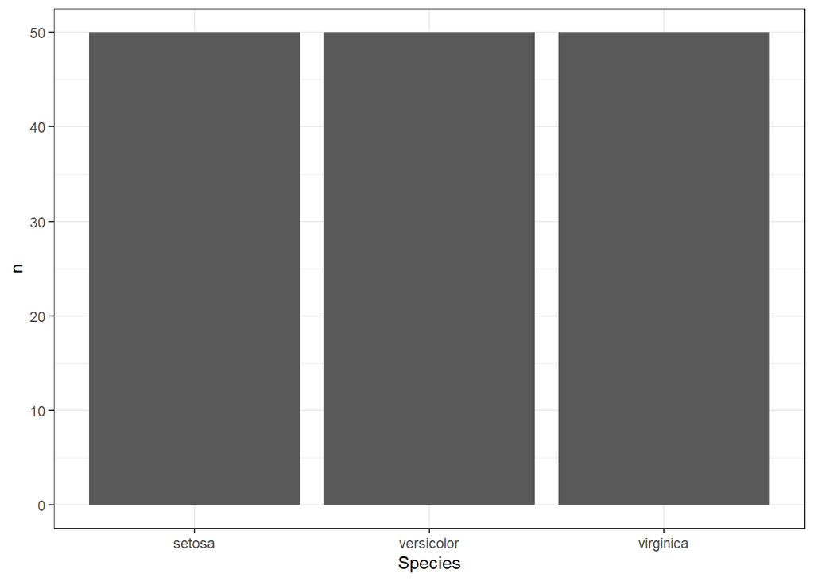

```r
iris %>%
  count(Species) %>%
  ggplot(mapping = aes(x = Species, y = n)) +
  geom_bar(stat = 'identity') +
  theme_bw()
```

Alternatively, we can use the `geom_col()` which does **not** perform statistical transformations.

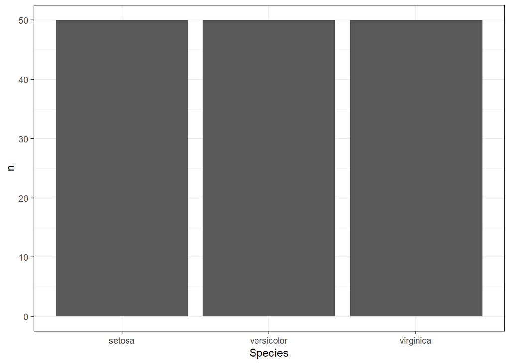

```r
iris %>%
  count(Species) %>%
  ggplot(mapping = aes(x = Species, y = n)) +
  geom_col() +
  theme_bw()
```

One last way to create a bar chart is with `stat_count()` directly where we force the `geom` to be `'bar'`.

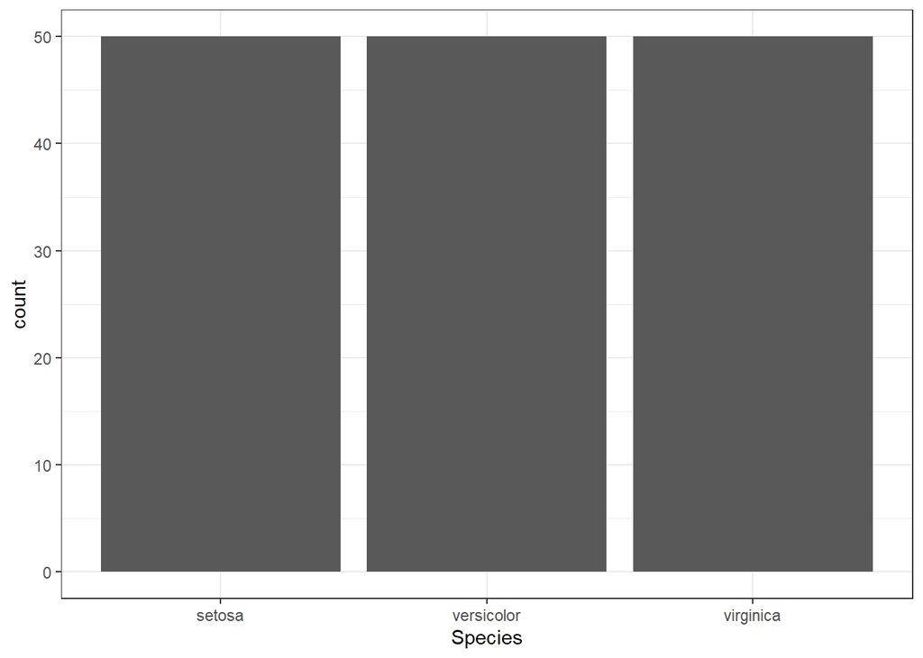

```r
iris %>%
  ggplot(mapping = aes(x = Species)) +
  stat_count(geom = 'bar') +
  theme_bw()
```

Include the count or the number of rows as text on top of the bars. We can instruct `geom_text()` to perform a statistical transformation and thus COUNT the number of rows.

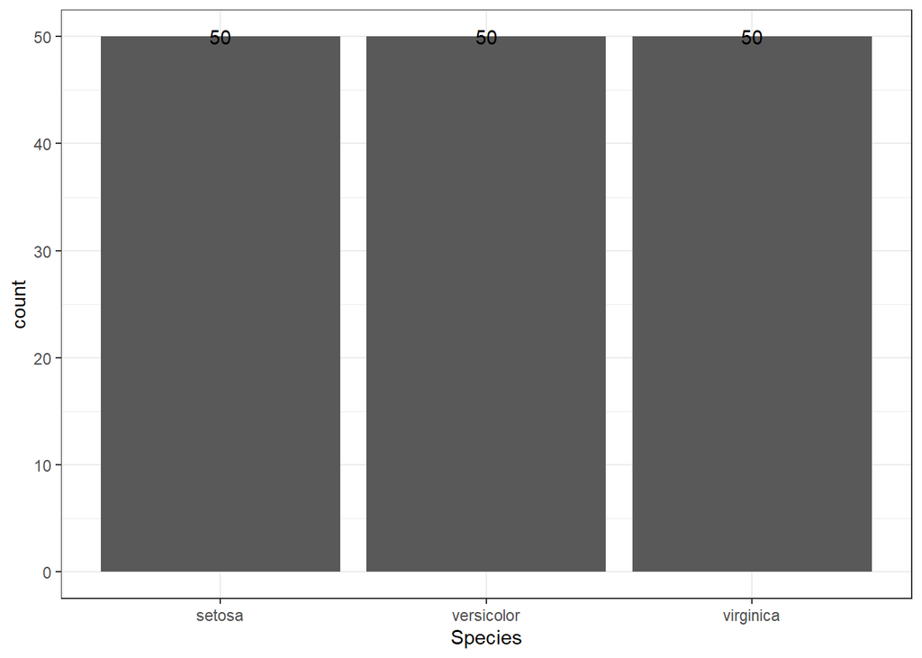

```r
iris %>%
  ggplot(mapping = aes(x = Species)) +
  geom_bar() +
  geom_text(stat = 'count',
            mapping = aes(label = stat(count))) +
  theme_bw()
```

We can manually “nudge” the position of the text.

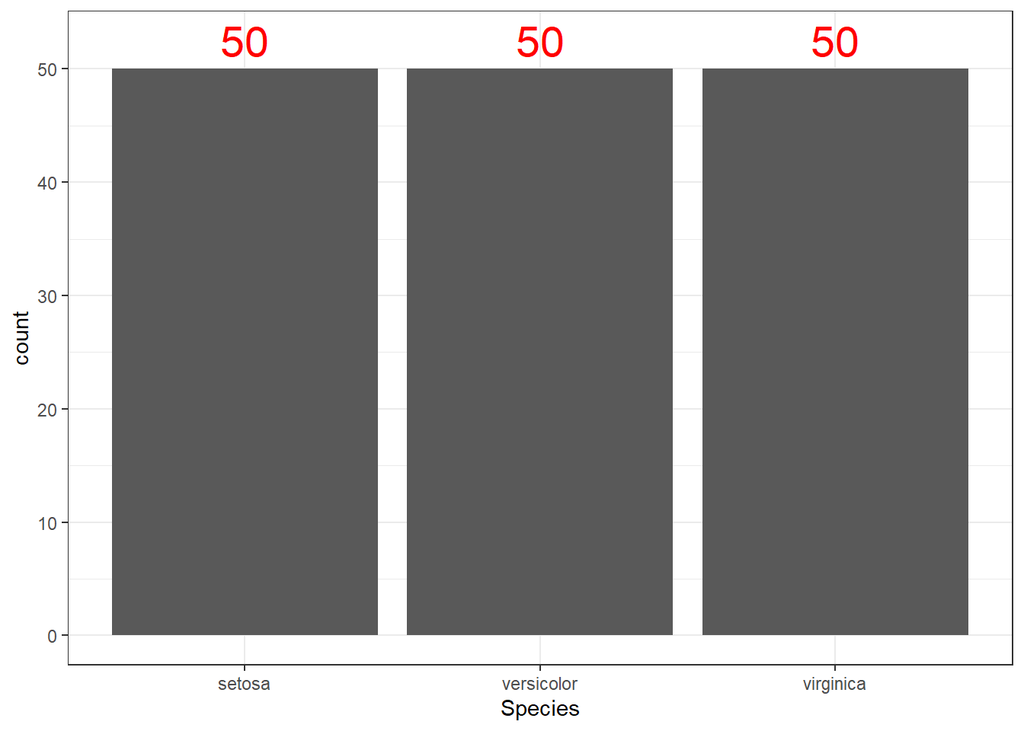

```r
iris %>%
  ggplot(mapping = aes(x = Species)) +
  geom_bar() +
  geom_text(stat = 'count',
            mapping = aes(label = stat(count)),
            nudge_y = 2.5, color = 'red', size = 7.5) +
  theme_bw()
```

We could “nudge” below the bar.

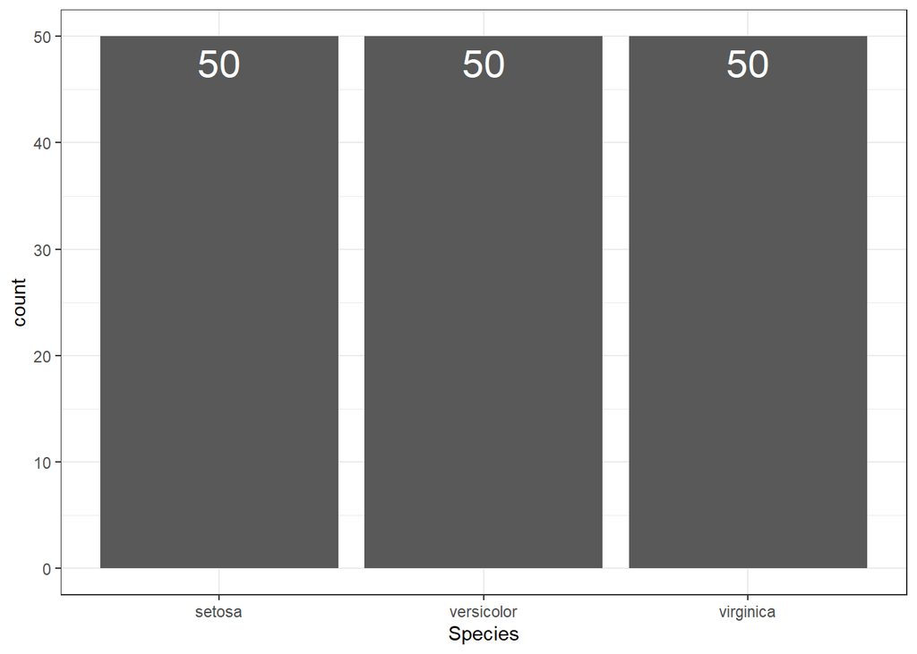

```r
iris %>%
  ggplot(mapping = aes(x = Species)) +
  geom_bar() +
  geom_text(stat = 'count',
            mapping = aes(label = stat(count)),
            nudge_y = -2.5, color = 'white', size = 7.5) +
  theme_bw()
```

We can also map Species to the fill of the bar.

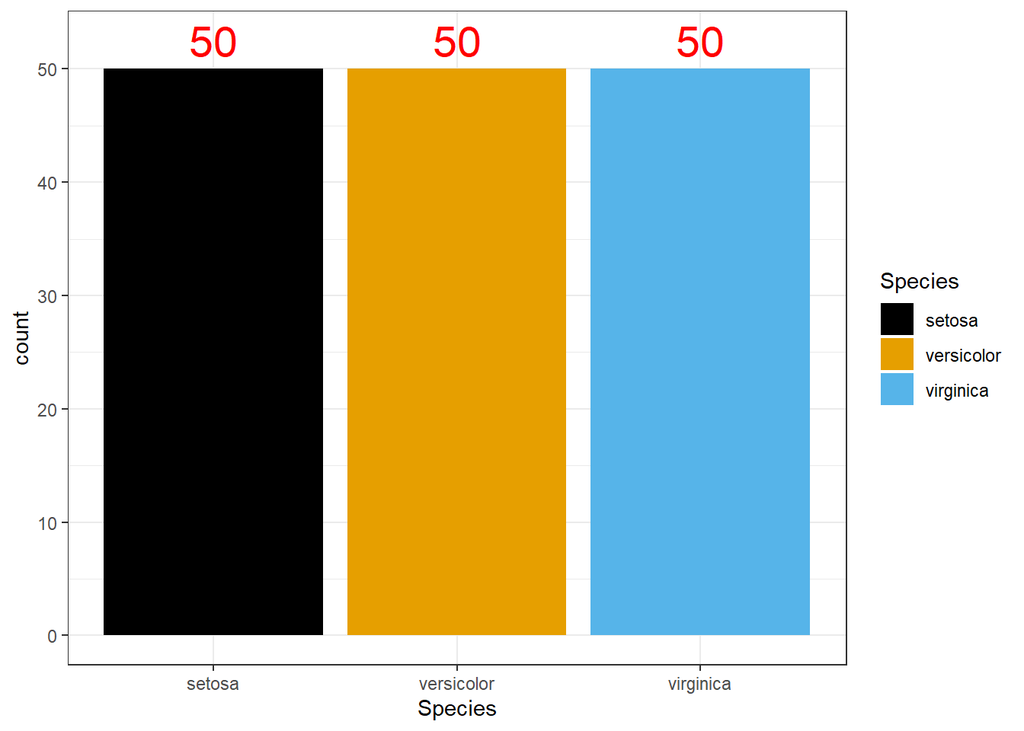

```r
iris %>%
  ggplot(mapping = aes(x = Species)) +
  geom_bar(mapping = aes(fill = Species)) +
  geom_text(stat = 'count',
            mapping = aes(label = stat(count)),
            nudge_y = 2.5, color = 'red', size = 7.5) +
  ggthemes::scale_fill_colorblind() +
  theme_bw()
```

We can turn off the legend since the x-axis is the fill.

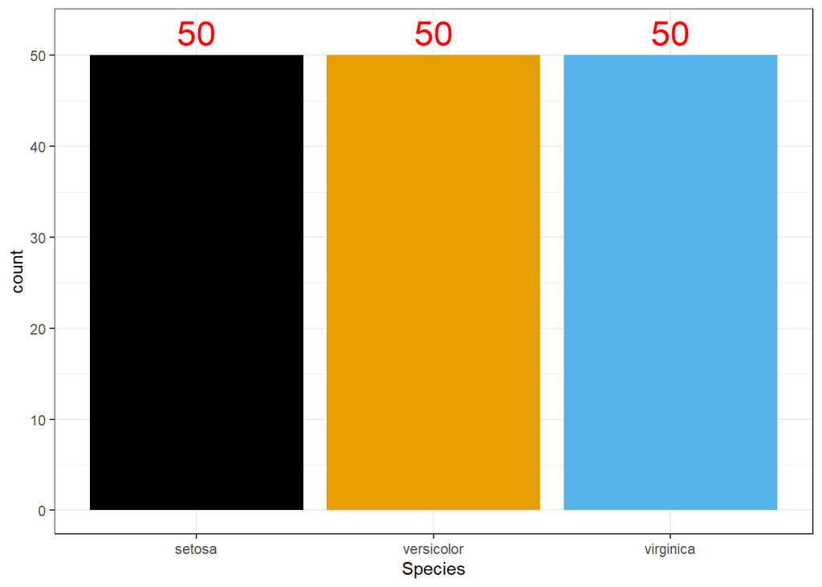

```r
iris %>%
  ggplot(mapping = aes(x = Species)) +
  geom_bar(mapping = aes(fill = Species)) +
  geom_text(stat = 'count',
            mapping = aes(label = stat(count)),
            nudge_y = 2.5, color = 'red', size = 7.5) +
  ggthemes::scale_fill_colorblind(guide=FALSE) +
  theme_bw()
```

Difference between fill and color.

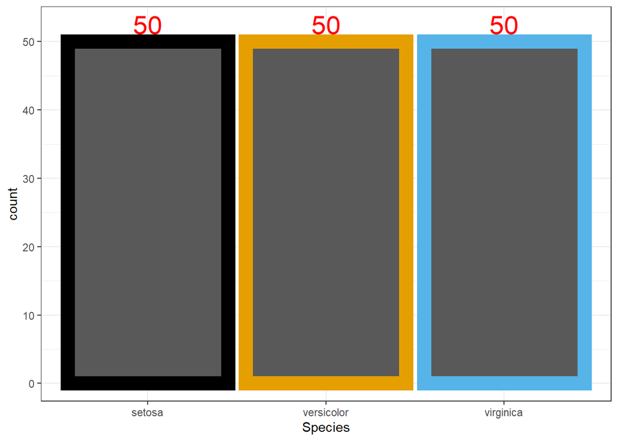

```r
iris %>%
  ggplot(mapping = aes(x = Species)) +
  geom_bar(mapping = aes(color = Species), size = 5.5) +
  geom_text(stat = 'count',
            mapping = aes(label = stat(count)),
            nudge_y = 2.5, color = 'red', size = 7.5) +
  ggthemes::scale_color_colorblind(guide=FALSE) +
  theme_bw()
```

Let’s create a binary variable based on the value `Sepal.Length` relative to the average `Sepal.Length`.

```r
mean(iris$Sepal.Length)
```

```
## [1] 5.843333
```

```r
iris %>% summarise(mean(Sepal.Length))
```

```
##   mean(Sepal.Length)
## 1           5.843333
```

Check the number of rows where `Sepal.Length` is greater than the average value.

```r
iris %>%
  filter(Sepal.Length > mean(Sepal.Length)) %>%
  nrow()
```

```
## [1] 70
```

Let’s visualize this as a bar chart.

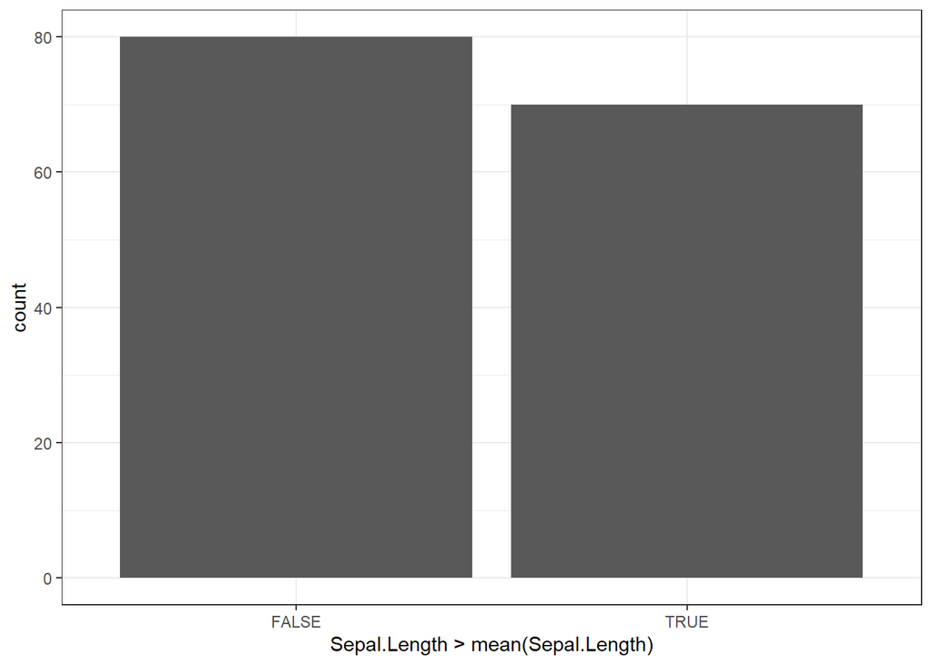

```r
iris %>%
  ggplot(mapping = aes(x = Sepal.Length > mean(Sepal.Length))) +
  geom_bar() +
  theme_bw()
```

How many rows per group have the `Sepal.Length` greater than the overall average?

```r
iris %>%
  mutate(length_bin = Sepal.Length > mean(Sepal.Length)) %>%
  count(Species, length_bin)
```

```
##      Species length_bin  n
## 1     setosa      FALSE 50
## 2 versicolor      FALSE 24
## 3 versicolor       TRUE 26
## 4  virginica      FALSE  6
## 5  virginica       TRUE 44
```

Visualize the counts with a bar chart.

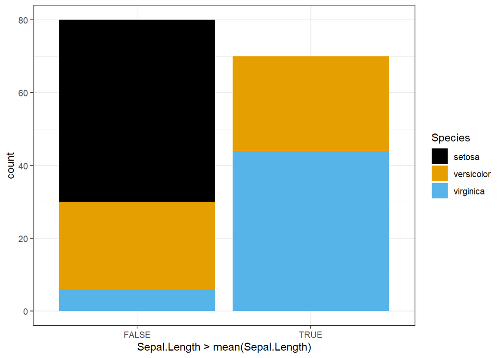

```r
iris %>%
  ggplot(mapping = aes(x = Sepal.Length > mean(Sepal.Length))) +
  geom_bar(mapping = aes(fill = Species)) +
  ggthemes::scale_fill_colorblind() +
  theme_bw()
```

I prefer to rearrange the fill into **separate** and **distinct** bars that are next to each other. In `ggplot2` this is known as **dodging** the position.

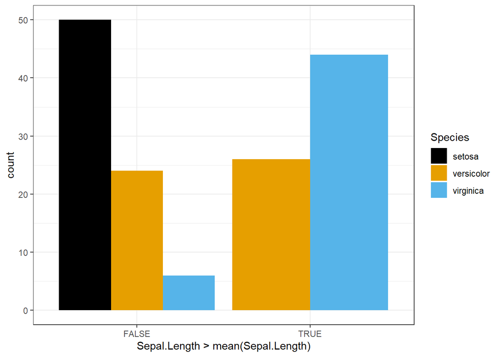

```r
iris %>%
  ggplot(mapping = aes(x = Sepal.Length > mean(Sepal.Length))) +
  geom_bar(mapping = aes(fill = Species),
           position = "dodge") +
  ggthemes::scale_fill_colorblind() +
  theme_bw()
```

We can also include the text for the counts. The `geom_text()` does **NOT** know the grouping structure.